# lab

**Convex and Distributed Optimization Lab**  
**MSIAM — Université Grenoble Alpes — 2018/2019**  
**Lecturers: Jérôme Malick, Yassine Laguel, Sélim Chraibi**  
**Authors: Shakirova Alevtina, Petrova Anastasia**

```python
# Automatic reload of local libraries
%load_ext autoreload
%autoreload 2
%reload_ext autoreload
%matplotlib inline
```

> **I. Introduction**  
> **II. The optimization problem**  
> **III. Implementing the solvers**  
> GD (Gradient descent))  
> SGD (Stochastic Gradient Descent))  
> SAGA (Stochastic Average Gradient "Amélioré"))  
> SVRG (Stochastic Variance Reduced Gradient))  
> Comparison  
> **IV. Regularization**  
> **V. Further development**

In this lab, you will implement optimization algorithms that you've studied in class and use them to fit a logistic regression classification model.

You will be implementing a simplified version of [`sklearn.linear_model.LogisticRegression`](https://scikit-learn.org/stable/modules/generated/sklearn.linear_model.LogisticRegression.html).

Part of the work has already been done for you (see the `\lib` folder), so you'll only have to implement the `##### TODO (i) #####` sections of the code. Whenever you complete such a section, we ask you to **copy it in this notebook**. We want you to **only send us a pdf or html export of this notebook** so we won't be able to see your work if it's not in this notebook.

Report in groups of 1 to 3 students.  
**Due date:** Monday, January 6, 2019 (before midnight).  
**Send to:** cdo.grenoble@gmail.com

# I. Introduction

We consider the [Student Performance](http://archive.ics.uci.edu/ml/datasets/Student+Performance) dataset. This dataset contains student demographic, social, school-related features, how many classes they've missed, etc.

The goal we give ourselves is to predict whether a student will pass (final grade > 12).

We denote $A \in \mathcal{M}_{n,d}(\mathbb{R})$ the feature matrix, containing $n$ samples with $d$ features, and $b \in \{-1,1\}^n$ the label vector where $-1$ encodes `fail` and $1$ encodes `pass`.

The data has already been preprocessed (yay less work for you 🎉). You can check `\lib\datasets.py` if you're curious, otherwise, you can just use the following to load your dataset:

```python
from lib.datasets import load_student_data

A_train, A_test, b_train, b_test = load_student_data('data/student-mat.csv', split=0.25)
```

As mentioned previously, you're going to implement a simplified version of [`sklearn.linear_model.LogisticRegression`](https://scikit-learn.org/stable/modules/generated/sklearn.linear_model.LogisticRegression.html). So let's first see what the finished product should look like.

**Question:**

- Import [sklearn.linear_model.LogisticRegression](https://scikit-learn.org/stable/modules/generated/sklearn.linear_model.LogisticRegression.html) .
- Create an instance of sklearn's logistic regression classifiers with SAGA as its solver.
- Fit the classifier on the training data and compute the score of the fitted model on the test set.

```python
from sklearn.linear_model import LogisticRegression
from sklearn.metrics import accuracy_score
model = LogisticRegression(solver = 'saga', max_iter=1000)
model.fit(A_train, b_train)
b_predict=model.predict(A_test)
print(accuracy_score(b_test,b_predict))
```

```
0.9191919191919192
```

# II. The optimization problem

Logistic regression consists in finding the parameter $x \in \mathbb{R}^d$ that best fits: $$ b_i = \begin{cases} \phantom{-}1 \ \textrm{ if }\ \langle a_{i}, x\rangle \ge 0 \\ -1 \ \textrm{ if }\ \langle a_{i}, x\rangle < 0 \end{cases} $$ for all the samples $i$ of the training set (where $a_i$ is the $i^{th}$ line of $A$ and $b_i$ the $i^{th}$ element of $b$). To measure this fit, logistic regression chooses the following loss:

$$ \textrm{LogisticLoss}(b_i, \left\langle a_{i}, x\right\rangle ) = \log \left(1+\exp \left(-b_{i}\left\langle a_{i}, x\right\rangle\right)\right) $$

The corresponding optimization problem we will consider is the following:

Minimization of the empirical risk $f$ of the $L_2$-regularized logistic regression model, on the dataset $(A_{\textrm{train}},b_{\textrm{train}})$: $$ \begin{aligned} \textrm{min}_{x\in \mathbb{R}^d} \ f(x) \ &= \ \textrm{min}_{x\in \mathbb{R}^d} \ \frac{1}{n_{\textrm{train}}} \sum_{i=1}^{n_{\textrm{train}}} f_i(x) \\ &= \ \textrm{min}_{x\in \mathbb{R}^d}\frac{1}{n_{\textrm{train}}} \sum_{i=1}^{n_{\textrm{train}}} \textrm{LogisticLoss}(b_i, \left\langle a_{i}, x\right\rangle ) + \frac{l_2}{2}\|x\|^{2}_2, \end{aligned} $$ where $l_2 \ge 0$ is the $L_2$ regularization coefficient.

To simplify the notation, we'll stop indexing $A$, $b$ and $n$ with "$\textrm{train}$" in the following.

**Question:** $f$ is $\mu$-strongly convex.

- Give a lower bound on $\mu$.
- Complete **TODO (1)** in **\lib\linear_model.py**.

> **Answer:**

> Let's consider LogisticLoss function:

> $$ \textrm{LogisticLoss}(b_i, \left\langle a_{i}, x\right\rangle ) = \log \left(1+\exp \left(-b_{i}\left\langle a_{i}, x\right\rangle\right)\right) $$

> It can be represented as a composition of two functions: 1)$h(x) = 1+\exp \left(-b_{i}\left\langle a_{i}, x \right\rangle\right)$

> This function is convex, as exponent is convex function.

> 2) $P(y)=\log (y)$

> This function is convex and non decrising.

> From mathematical analysis we know the following property:

> Let $ h (x)$ be a convex function, $P (y)$ be convex and non-decreasing. Then $f (x) = P (h (x))$ - convex function.

> So, LogisticLoss function is convex function.

> We also know the following property:

> The sum of convex functions is a convex function.

> So, $ \sum_{i=1}^{n_{\textrm{train}}} \textrm{LogisticLoss}(b_i, \left\langle a_{i}, x\right\rangle)$ is convex.

> Function min is also a convex fuction, so $\textrm{min}_{x\in \mathbb{R}^d} \frac{1}{n_{\textrm{train}}} \sum_{i=1}^{n_{\textrm{train}}} \textrm{LogisticLoss}(b_i, \left\langle a_{i}, x\right\rangle)$ is convex.

> We know that function $f(x)$ is $\mu$-strongly convex if $f(x) - \frac{\mu}{2}||x||^2$ is convex.

> So, for our function to be $\mu$-strongly convex it is need the substracted term does not exceed $\frac{l_2}{2}\|x\|^{2}_2$.

> Thus, the low bound on $\mu$ is, $\mu = l_2$

**Question:** Denote $\lambda_{\max}$ the largest eigenvalue of the real symmetric matrix $AA^T$.

- Prove that $\lambda_{\max}(\nabla^2 f_i) \le \lambda_{\max}(\frac{a_i a_i^T}{4} + l_2 I_d)$
- Prove that $\lambda_{\max}(a_i a_i^T) \le \|a_i\|^2_2$

> **Answer:**

> 1) Сalculate the partial derivative $\frac{\partial f_i(x)}{\partial x}$:

> \begin{equation} \frac{\partial f_i(x)}{\partial x} =\frac{\partial}{\partial x}\left[ \log\big[ 1 + \exp \left\{ -b_{i}\left\langle a_{i}, x\right\rangle \right\} \big] + \frac{l_2}{2} \| x \|^2\right ] = -b_i a_i \frac{ \exp \left\{ -b_{i}\left\langle a_{i}, x\right\rangle \right\}}{1 + \exp \left\{ -b_{i}\left\langle a_{i}, x\right\rangle \right\} } +l_2 \cdot x = -b_i a_i \frac{1}{\exp \left\{ b_{i}\left\langle a_{i}, x\right\rangle \right\}+1}+l_2 \cdot x. \end{equation}

> 2) Calculate the Hessian: \begin{equation} \nabla^2 f_i(x) = \nabla^2 \left[\log\big[ 1 + \exp \left\{ -b_{i}\left\langle a_{i}, x\right\rangle \right\} \big] + \frac{l_2}{2} \| x \|^2\right ]=-b_i^2 a_i a_i^T\frac{\exp \left\{ b_{i}\left\langle a_{i}, x\right\rangle \right\}}{\left [1 + \exp \left\{ b_{i}\left\langle a_{i}, x\right\rangle \right\}\right ]^2}+l_2 \cdot I_d. \end{equation}

> 3) Let's denote $z(x) = \frac{\exp \left\{ b_{i}\left\langle a_{i}, x\right\rangle \right\}}{\left [1 + \exp \left\{ b_{i}\left\langle a_{i}, x\right\rangle \right\}\right ]^2}$ and find its maximum value. To do this, we introduce the following replacement: $r(x) = \exp \left\{ b_{i}\left\langle a_{i}, x\right\rangle \right\}$, $r > 0$. Then, we can write the following: $z_1(r)=\frac{r}{(r+1)^2}$. Let's find the optimal value of $z_1(r)$. For this we need to compute the derivative : $\frac{d\ z_1}{d\ r} = \frac{1-r^2}{(1+r)^2}. $ Hence, the maximum value is reached at point $r_{\max} = 1$ (because $r > 0$) and is equal to $z_{1_{\mathrm{opt}}} = \frac{1}{4}$

> 4) We know that if matrix $C$ has the following form: $C =B^{T} B$ then $\lambda_{\max}[C]$ is a square of a matrix norm $\| B \|_2$ of matrix $B$, where $\| B \|_2= \sup\limits_{\| x \|_2 = 1} \| B x \|.$

> Taking into account that $ b^2 = 1$, the result of 3) and the definition of spectral norm, we will get the following result:

> \begin{equation} \lambda_\max\left[ \nabla^2 f_i(x) \right] = \lambda_\max \left [ -\underbrace{b_i^2}_{=1} a_i a_i^T \underbrace{\frac{\exp \left\{ b_{i}\left\langle a_{i}, x\right\rangle \right\}}{\left [1 + \exp \left\{ b_{i}\left\langle a_{i}, x\right\rangle \right\}\right ]^2}}_{\leq \frac{1}{4}}+l_2 \cdot I_d \right ] \leq \lambda_\max \left[ \frac{a_i a_i^T}{4} +l_2 I_d \right]. \end{equation}

> Thus, the first inequality is proved: $\lambda_\max\left[ \nabla^2 f_i(x) \right] \leq \lambda_\max \left[\frac{a_i a_i^T}{4} +l_2 I_d\right]$

> 5)Now we need to show that $\lambda_{\max}(a_i a_i^T) \le \|a_i\|^2_2$ . To do this we will consider the properties of Frobenius norm which can be defind as $\|F\|_{F}^{2}=\sum_{i=1}^{m}\sum_{j=1}^{n}|f_{i,j}|^2$. For Frobenius norm the following holds: $\| F x \|_2 \leq\| F \|_F \| x \|_2=\sqrt{\sum_{i, j = 1}^{n} f^2_{ij}}\cdot\| x \|_2.$

> If re-designate $a_i$ as $a$ then: $$\| a_i a_i^T \|_F =\sqrt{\sum\limits_{k=1 }^n a^4_k+2 \sum\limits_{k, j = 1 \\ k \neq j}^n a^2_k a^2_j}=\sqrt{\left(\sum\limits_{k = 1}^n a_k^2\right)^2}=\left|\sum\limits_{k = 1}^n a_k^2\right|=\| a \|^2_2.$$

> Using the result above, we get the following: $\lambda_{\max}(a_i a_i^T) \le \|a_i\|^2_2$

> Thus, the second inequality is proved.

A consequence of these results is that the $f_i$s and $f$ are all $L$-smooth with $L \le \frac{\max_i\|a_i\|^2_2}{4} + l_2$ and we can therefore use the following value in our implementation:

```
L = 0.25 * max(np.linalg.norm(A,2,axis=1))**2 + self.l2
```

# III. Implementing the solvers

To implement gradient methods, we need an oracle that will compute both batch gradients $\nabla f$ and partial gradients $\nabla f_i$.

**Question:** In the code below, $\nabla f$ has already been implemented.

- Complete **TODO (2)** bellow.
- Add your code to **\lib\linear_model.py**.

```python
import numpy as np
```

```python
def grad(x, i=None):
    '''
    Gradient of the objective function at x.
    If no i is given, grad should return the batch gradient.
    Otherwise, it should return the partial gradient associated the the datapoint (A[i], b[i]).
    '''

    if i is None: # return batch gradient
        output = -b/(1 + np.exp(b*np.dot(A, x)))
        output = sum(np.diag(output))/n @ A
        output += self.l2*x
    else: # return partial gradient associated the datapoint (A[i], b[i])
        output = -np.sign(b[i])*A[i]/(1 + np.exp(np.sign(b[i])*np.dot(A[i], x)))
        output += self.l2*x
        ######## TODO (2) ########
        pass
    return output
```

# GD (Gradient descent)

At iteration k of the GD algorithm, the following update is executed:

$$ x_{k+1} \leftarrow x_{k} - \gamma\nabla f(x_k) $$

**Question:**

- What stepsize $\gamma$ ensures the convergence of this algorithm and under what assumptions?
- Complete **TODO (3)** and **TODO (4)**
- Add your code to **\lib\solvers.py**.

> **Answer:** We chose stepsize $\gamma = \frac{1}{L}$ (it defined by Lipschitz constant $L$ of gradient of function $f$ (it is a theoretical value and can be find in literature) and ensures the convergence of this algorithm).

```python
def GD(x0, grad, max_iter, n, L, mu):
    '''
    Parameters
    ----------
    x0: array, shape (nb_features,)
        Initialisation of the solver
    grad: function
        Gradient of the objective function
    max_iter: int
        Number of iterations (i.e. number of descent steps). Note that for GD or SVRG,
        one iteration is one epoch i.e, one pass through the data, while for SGD, SAG and SAGA,
        one iteration uses only one data point.
    n: int
        Dataset size
    L: float
        Smoothness constant of the objective function
    mu: float
        Strong convexity constant of the objective function

    Returns
    -------
    x: array, shape (nb_features,)
        final iterate of the solver
    x_tab: array, shape (nb_features, max_iter)
        table of all the iterates
    '''
    stepsize  = 1.0/L ######## TODO (3) ########
    x         = x0
    x_tab     = np.copy(x)

    for k in range(max_iter):
        x     = x - stepsize*grad(x)######## TODO (4): Implement a single step ########
        x_tab = np.vstack((x_tab, x))

    return x, x_tab
```

**Question:** Run the code below to test your code.

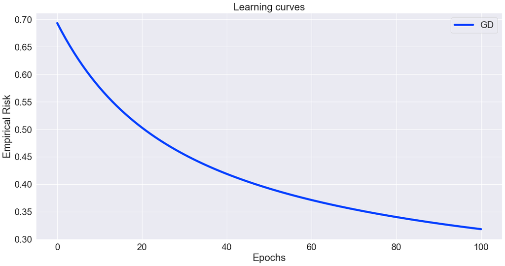

```python
from lib.linear_model import LogisticRegression
from lib.visuals import learning_curve

clf_gd = LogisticRegression(solver='gd', l2=0.01, max_iter=100)
clf_gd.fit(A_train, b_train)

learning_curve(GD=clf_gd)
```

# SGD (Stochastic Gradient Descent)

At iteration k of the SGD algorithm, the following update is executed:

$$ \begin{cases} i \textrm{ chosen randomly in } \{1...n\}\\ x_{k+1} \leftarrow x_{k} - \gamma_k \nabla f_i(x_k) \\ \end{cases} $$

**Question:**

- What stepsize $\gamma_k$ ensures the convergence of this algorithm and under what assumptions?
- Complete **TODO (5)**
- Add your code to **\lib\solvers.py**.

```python
def SGD(x0, grad, max_iter, n, L, mu):
    ######## TODO (5) ########
    step = 1.0/L
    x = x0
    x_tab = np.copy(x)
    for k in range(max_iter):
        i=np.random.choice(n)
        x = x - step*grad(x,i)
        ######## TODO (5) ########

        if k%n == 0: # each completed epoch
            x_tab = np.vstack((x_tab, x))

    return x, x_tab
```

**Question:** Run the code below to test your code.

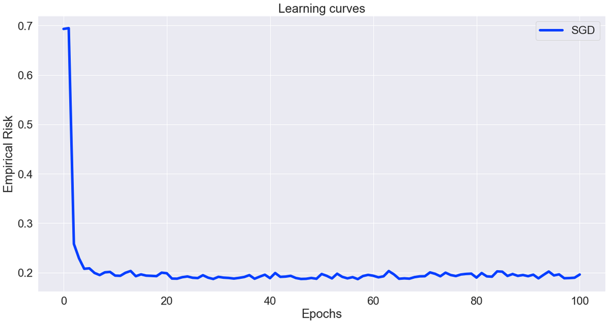

```python
clf_sgd = LogisticRegression(solver='sgd', l2=0.01, max_iter=100*len(b_train))
clf_sgd.fit(A_train, b_train)

learning_curve(SGD=clf_sgd)
```

# SAGA (Stochastic Average Gradient "Amélioré")

SAGA starts by computing a single batch gradient, then at iteration k, the following update is executed:

$$ \begin{cases} i \textrm{ chosen randomly in } \{1...n\}\\ x_{k+1} \leftarrow x_{k} - \gamma_k\big(\nabla f_i(x_k) - \alpha_i + \bar{\alpha}\big) \\ \alpha_i \leftarrow \nabla f_i(x) \end{cases} $$

where $(\alpha_j)_{j=1}^n$ are gradients evaluated at previous iterates and $\bar{\alpha}=\frac{1}{n}\sum^n_{j=1}\alpha_j$.

**Question:**

- What stepsize $\gamma_k$ ensures the convergence of this algorithm and under what assumptions?
- Complete **TODO (6)**
- Add your code to **\lib\solvers.py**.

```python
def SAGA(x0, grad, max_iter, n, L, mu):
    ######## TODO (6) ########
    stepsize = 1.0/L
    x = x0
    x_tab = np.copy(x)
    alpha_i=np.zeros((len(x0), n))
    for l in range(n):
            alpha_i[:,l] = grad(x,l)
    alpha = np.mean(alpha_i,axis=1)

    for k in range(max_iter):
        i=np.random.choice(n)
        grad_k=grad(x,i)
        x = x - stepsize*(grad_k- alpha_i[:,i] + alpha)
        alpha_i[:,i]=grad_k
        alpha = np.mean(alpha_i,axis=1)

        ######## TODO (6) ########

        if k%n == 0: # each completed epoch
            x_tab = np.vstack((x_tab, x))

    return x, x_tab
```

**Question:** Run the code below to test your code.

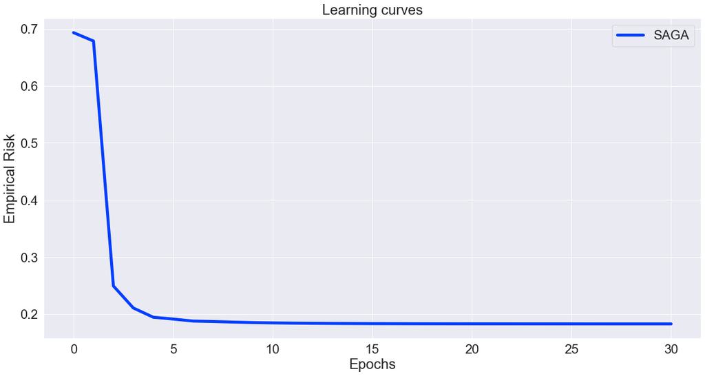

```python
clf_saga = LogisticRegression(solver='saga', l2=0.01, max_iter=30*len(b_train))
clf_saga.fit(A_train, b_train)

learning_curve(SAGA=clf_saga)
```

# SVRG (Stochastic Variance Reduced Gradient)

At iteration k of the SVRG algorithm, we perform the following:

$$ \begin{cases} \textrm{Compute the batch gradient } \nabla f(x_k)\\ \textrm{Initialise }y_0 = x_k\\ \textrm{for m in 0...M-1: } \begin{cases} i \textrm{ chosen randomly in } \{1...n\} \\ y_{m+1} \leftarrow y_{m} - \gamma_k\big(\nabla f_i(y_m) - \nabla f_i(x_k) + \nabla f(x_k)) \end{cases}\\ x_{k+1} \leftarrow y_{M} \end{cases} $$

**Question:**

- What stepsize $\gamma_k$ ensures the convergence of this algorithm and under what assumptions?
- Complete **TODO (7)**
- Add your code to **\lib\solvers.py**.

```python
def SVRG(x0, grad, max_iter, n, L, mu):
    ######## TODO (7) ########
    stepsize = 1.0/L
    x = x0
    y=np.copy(x0)
    x_tab = np.copy(x)
    alpha_i=np.zeros((len(x0), n))

    for k in range(max_iter):
        for l in range(n):
            alpha_i[:,l] = grad(x,l)
        alpha = np.mean(alpha_i,axis=1)
        y = x
        for j in range (100):
            i=np.random.choice(n)
            y = y - stepsize*(grad(y,i)- alpha_i[:,i] + alpha)
        ######## TODO (7) ########
        x = y

        x_tab = np.vstack((x_tab, x))

    return x, x_tab
```

**Question:** Run the code below to test your code.

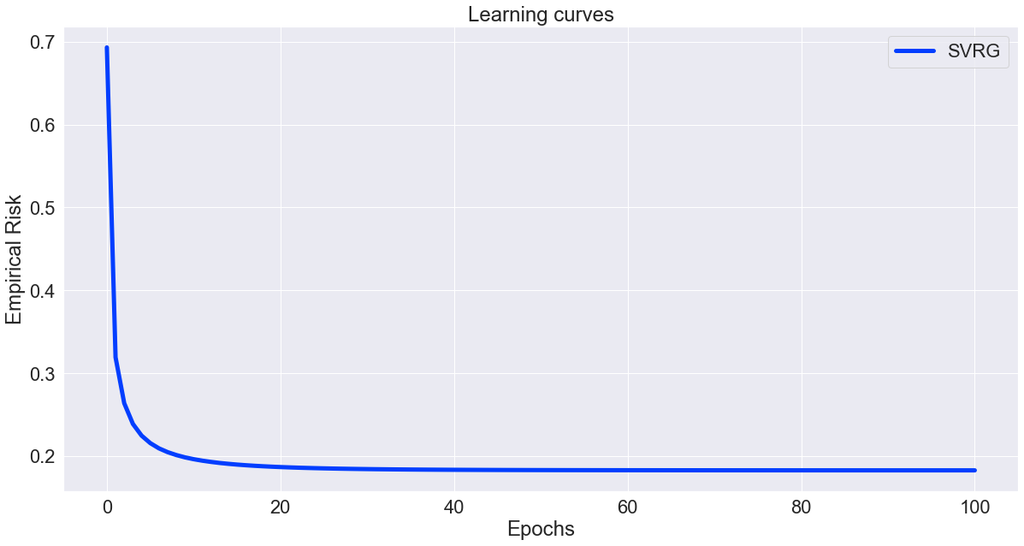

```python
clf_svrg = LogisticRegression(solver='svrg', l2=0.01, max_iter=100)
clf_svrg.fit(A_train, b_train)

learning_curve(SVRG=clf_svrg)
```

# Comparison

**Question:** Run the code below to compare all the methods you've implemented.

```python
epochs = 40
n = len(b_train)

clf_gd   = LogisticRegression(solver='gd', l2=0.01, max_iter=epochs)
clf_sgd  = LogisticRegression(solver='sgd', l2=0.01, max_iter=epochs*n)
clf_saga = LogisticRegression(solver='saga', l2=0.01, max_iter=epochs*n)
clf_svrg = LogisticRegression(solver='svrg', l2=0.01, max_iter=epochs)

clf_gd.fit(A_train, b_train)
clf_sgd.fit(A_train, b_train)
clf_saga.fit(A_train, b_train)
clf_svrg.fit(A_train, b_train)
```

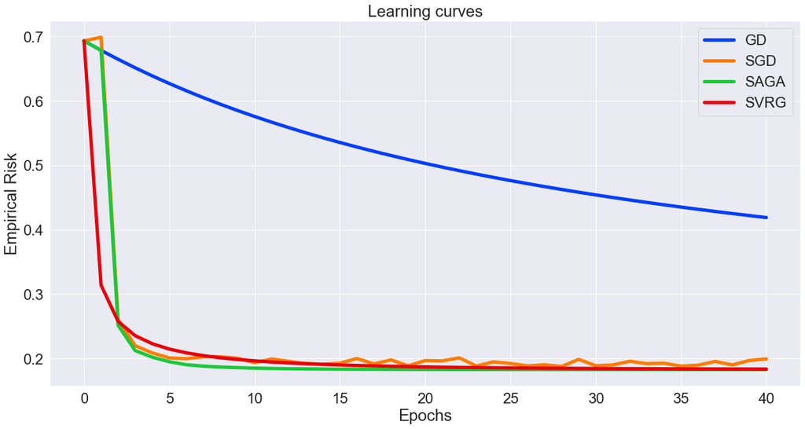

```
gd:	Accuracy on training set: 88.9%
	Accuracy on testing set:  85.9%
sgd:	Accuracy on training set: 92.9%
	Accuracy on testing set:  89.9%
saga:	Accuracy on training set: 93.9%
	Accuracy on testing set:  90.9%
svrg:	Accuracy on training set: 93.6%
	Accuracy on testing set:  90.9%
```

```python
learning_curve(GD=clf_gd, SGD=clf_sgd, SAGA=clf_saga, SVRG=clf_svrg)

for clf, name in zip([clf_gd, clf_sgd, clf_saga, clf_svrg], ['gd', 'sgd', 'saga', 'svrg']):
    print(name + ':' \
          + "\tAccuracy on training set: {0:0.1f}%".format(100*clf.score(A_train, b_train)))
    print("\tAccuracy on testing set:  {0:0.1f}%".format(100*clf.score(A_test, b_test)))
```

# IV. Regularization

**Question:**

- Rewrite the empirical risk minimization objective with both $L_1$ and $L_2$ regularization (with coefficients $l_1$ and $l_2$).
- Is this objective $\mu$-strongly convex, $L$-smooth, differentiable?
- Complete the **TODO (8)** to account for the new term in the objective.
- Add your code to **lib/linear_model.py**.

> **Answer:**

> In the previous task we considered the empirical risk minimization objective with $𝐿_2$ regularization:

> $$ \textrm{min}_{x\in \mathbb{R}^d} \ f(x) = \textrm{min}_{x\in \mathbb{R}^d}\frac{1}{n_{\textrm{train}}} \sum_{i=1}^{n_{\textrm{train}}} \textrm{LogisticLoss}(b_i, \left\langle a_{i}, x\right\rangle ) + \frac{l_2}{2}\|x\|^{2}_2, $$

> where $l_2 \ge 0$ is the $L_2$ regularization coefficient.

> Now we want to rewrite the empirical risk minimization objective with both $L_1$ and $𝐿_2$ regularization. The result is the following:

> $$ \textrm{min}_{x\in \mathbb{R}^d} \ f(x) = \textrm{min}_{x\in \mathbb{R}^d}\frac{1}{n_{\textrm{train}}} \sum_{i=1}^{n_{\textrm{train}}} \textrm{LogisticLoss}(b_i, \left\langle a_{i}, x\right\rangle ) +l_1\|x\|_1+ \frac{l_2}{2}\|x\|^{2}_2. $$

> 1) This new objective function is still $\mu$-strongly convex because $\|x\|_1$ is convex, and as it was written previously the objective function only with $L_2$ regularization is also convex. From mathematical analysis we know that the sum of two convex functions is convex, so our new objective function is also convex.

> a) let's prove that all three terms are Lipschitz:
> - The first term is smooth, because it is twice differentiable function and for such type of functions the following holds:

> $$\| \nabla f(x) - \nabla f(y) \| \leq L \| x - y \|$$
> - Our second and third terms are norms. Let's consider $f(x) = \|x\|$ and show that $f(x)$is L-smooth, using the triangular inequation:

> $\| f(y)-f(x)\| =\left \| \|y\|-\|x\|\right \| \leq L \cdot \|y -x \|,$ where $L=1$.

> b) The sum of Lipschitz functions is $L-$smooth.

> 3) This new objective function is not differentiable because $l_1-$term is not differentiable in 0, so the whole function is not differentiable in 0.

```
self._empirical_risk = lambda x: sum(self._logistic_loss(A, b, x))/n \
                                 + self.l2/2.0 * np.linalg.norm(x,2) \
                                 + self.l1 * np.linalg.norm(x, 1)
```

The minimization algorithms we've implemented have a slow rate of convergence for this new objective function. We will therefore use *proximal* variations of these algorithms.

**Question:** Using the $\textrm{prox}_{l_1 \|\cdot\|_1}$ operator, write down the $k^{th}$ step of proximal GD, proximal SGD, proximal SAGA, and proximal SVRG.

> **Answer:** We will not rewrite the unchanged parts but only parts that should be changed:

> 1) At iteration k of the GD algorithm, the following update is executed:

> $$ x_{k+1} \leftarrow x_{k} - \gamma\nabla f(x_k) $$

> Thus, the $k^{th}$ step of Proximal GD:

> $$ x_{k+1} = \textrm{prox}_{l_1 \|\cdot\|_1} \left [ x_{k } - \gamma_{k} \nabla f \left( x_{k} \right)\right ] $$

> 2) At iteration k of the SGD algorithm, the following update is executed:

> $$ \begin{cases} i \textrm{ chosen randomly in } \{1...n\}\\ x_{k+1} \leftarrow x_{k} - \gamma_k \nabla f_i(x_k) \\ \end{cases} $$

> Thus, the $k^{th}$ step of Proximal SGD:

> $$ x_{k+1} = \textrm{prox}_{l_1 \|\cdot\|_1} \left [ x_{k } - \gamma_{k} \nabla f_{i} \left( x_{k} \right)\right ] $$

> 3) SAGA starts by computing a single batch gradient, then at iteration k, the following update is executed:

> $$ \begin{cases} i \textrm{ chosen randomly in } \{1...n\}\\ x_{k+1} \leftarrow x_{k} - \gamma_k\big(\nabla f_i(x_k) - \alpha_i + \bar{\alpha}\big) \\ \alpha_i \leftarrow \nabla f_i(x) \end{cases} $$

> where $(\alpha_j)_{j=1}^n$ are gradients evaluated at previous iterates and $\bar{\alpha}=\frac{1}{n}\sum^n_{j=1}\alpha_j$.

> Thus, the $k^{th}$ step of Proximal SAGA:

> $$ x_{k+1} = \textrm{prox}_{l_1 \|\cdot\|_1} \left [ x_{k} - \gamma_{k}\left( \nabla f_{i} \left( x_{k} \right) -\alpha_i + \bar{\alpha}\right )\right] $$

> 4) At iteration k of the SVRG algorithm, we perform the following:

> $$ \begin{cases} \textrm{Compute the batch gradient } \nabla f(x_k)\\ \textrm{Initialise }y_0 = x_k\\ \textrm{for m in 0...M-1: } \begin{cases} i \textrm{ chosen randomly in } \{1...n\} \\ y_{m+1} \leftarrow y_{m} - \gamma_k\big(\nabla f_i(y_m) - \nabla f_i(x_k) + \nabla f(x_k)) \end{cases}\\ x_{k+1} \leftarrow y_{M} \end{cases} $$

> Thus, the $k^{th}$ step of Proximal SVRG:

> $$ y_{m+1} = \textrm{prox}_{l_1 \|\cdot\|_1} \left [ y_{m} - \gamma_{k}\left( \nabla f_{i} \left( y_{m} \right) - \nabla f_{i} \left( x_{k} \right) + \nabla f \left( x_{k} \right) \right )\right] $$

**Question:**

- Give a closed-form expression of $\textrm{prox}_{l_1 \|\cdot\|_1}$
- Complete **TODO (9)** (note that you can access the $l_1$ coefficient using **self.l1**).
- Add your code to **\lib\linear_model.py**.

> **Answer:**

> The proximity operator of a convex function $f$ at $x$ is defined as the unique solution to $\arg\min_{y} ( f(y) + \frac{1}{2}\|y -x\|^2 )$.

> In our task $f(x) = l_1 \| x \|_1 $, so $\textrm{prox}_{l_1 \|\cdot\|_1}x = \arg\min_{y}( l_1 \|y\|_1 + \frac{1}{2}\|y -x\|_1^2 )$. We consider $y \in R^n$, but in this case we can separate our task into $n$ tasks: $\arg\min_{y} ( l_1|y_i| + \frac{1}{2}(y_i -x_i)^2 )$.

> $$ |y_i| = \begin{cases} y_i, \ y_i > 0\\ -y_i, \ y_i < 0\\ 0, \ y_i =0 \end{cases} $$

> Let's compute the subderivative of $l_1|y_i| + \frac{1}{2}(y_i -x_i)^2$. We obtained the following result:

> $$ \begin{cases} y_i=x_i -l_1, \ y_i > 0\\ y_i =x_i +l_i, \ y_i < 0\\ [-1,1], \ y_i =0 \end{cases} $$

> Consider 3 possible variants of $y_i$: positive, negative and zero. If $y_i$ is positive, then derivative will be $y_i - x_i + l_1$, hence $y_i = x_i - l_1$. If $y_i$ is negative, then derivative will be $y_i = x_i + l_1$. If $y_i = 0$, then derivative $y_i \in [-1;1]$.

> Thus,:

> $$ \mathrm{prox}_{l_1 \|\cdot\|_1}x = \mathrm{sign}(x_i)\cdot \max\{|x_i| - l_1, 0\} $$

```python
def prox(x, stepsize):
    ######## TODO (9) ########
    if self.l1:
        return np.sign(x)*np.max(np.abs(x)-self.l1*stepsize, 0)
    return x
```

**Question:**

- Add **prox** to the attributes of the solvers (both in the call to **self.solver** in **/lib/linear_model.py** and in **/lib/solvers.py**) as follows:  
  solver(x0, grad, **prox**, self.max_iter, n, L, mu)
- Add a proximal step to all the algorithms in **/lib/solvers.py**.
- Paste one of these algorithms in the cell bellow.

```python
def SGD(x0, grad, prox, max_iter, n, L, mu):
    stepsize = 1.0/L
    x = x0
    x_tab = np.copy(x)
    for k in range(max_iter):
        i=np.random.choice(n)
        x = x - stepsize*grad(x,i)
        x = prox (x, stepsize)
        if k%n == 0:
            x_tab = np.vstack((x_tab, x))

    return x, x_tab
```

**Question:** If your proximal gradient descent is correctly implemented, the following cell will plot the support of the solution for various values of $l_1$.

- Interpret the plot and explain what can $L_1$ regularization be used for.

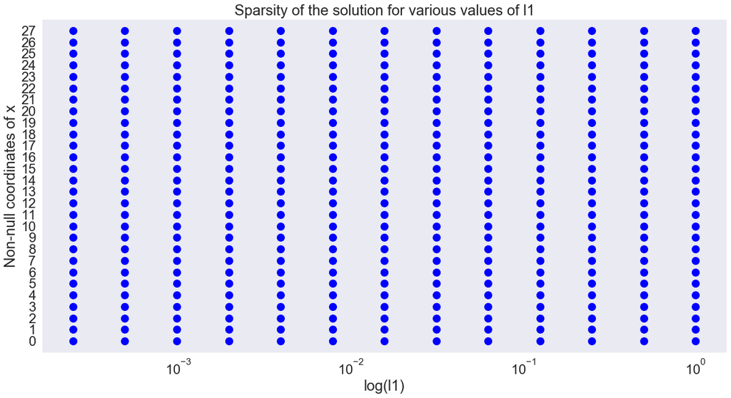

```python
from lib.visuals import l1_regularization_plot

clf = lambda l1: LogisticRegression(solver='gd', l1=l1, l2=0.1, max_iter=1000)

l1_regularization_plot(clf, A_train, b_train)
```

**Question:** The following cell will plot the value of the coordinates of the solution for various values of $l_2$.

- Interpret the plot and explain what can $L_2$ regularization be used for.

> **Answer:** We think that $L_2$ regularisation can be used to bound the absolute value of parameters vector, because as it can be seen from the plot if we choos the correct value of $l_2$ then the norm of $x$ can be really small. It can help to cope with overfitting.

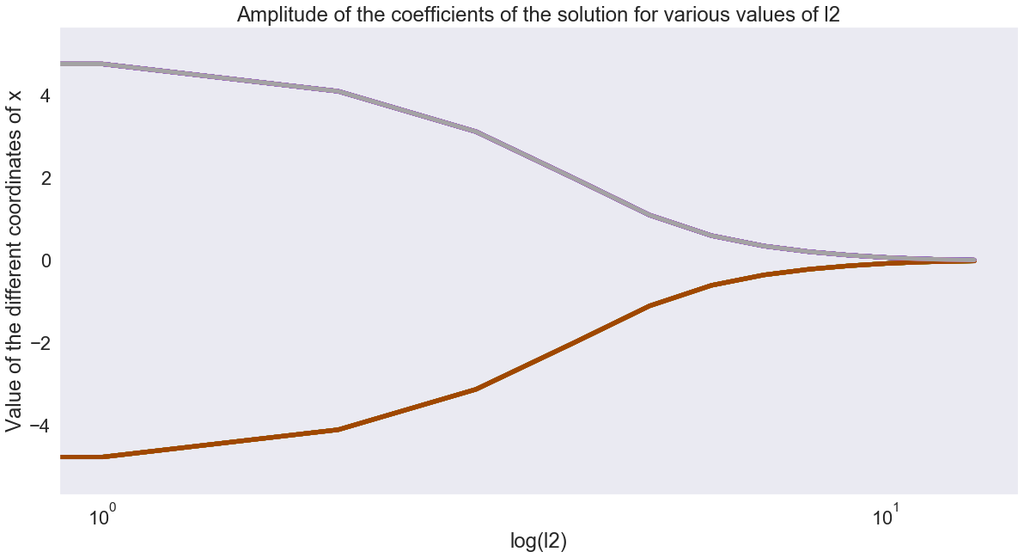

```python
from lib.visuals import l2_regularization_plot

clf = lambda l2: LogisticRegression(solver='gd', l1=0.01, l2=l2, max_iter=1000)

l2_regularization_plot(clf, A_train, b_train)
```

# V. Further development

Since we were a little bit familiar with the proposed optimization methods, we decided to look at how these methods can be interpreted in relation to a well-known economic problem — **resource allocation problem**. We will try to modify SGD, SAG and SAGA for that problem, give economic interpretations of the methods, highlight the advantages and disadvantages, and conduct a numerical comparison of the three methods. In the end, we will try to give recommendations for the use of methods in resource allocation problem of different dimensions.

## Motivation

Resource allocation problem is widely applied in many areas. However, existing methods at each step calculate the full gradient, i.e. all producers generate demand at one time. And this is not always the case in reality. Therefore, our methods are suitable for online activities. One manufacturer comes in. Purpose of the investigation is to give an approach to solve the resource allocation problem using methods of randomization of the sum.

We had the following aims:

- provide a modified algorithms for the task, as well as its economic interpretation;
- highlight their advantages and disadvantages;
- conduct a numerical comparison of the three methods.

## Problem statement

Suppose there is an owner of $k$ resources with a volume vector $b\in R_{+}^k$. In addition, there are $n$ manufacturers that produce $m$ types of goods in the volume of $x_i \in R_{+}^m$. Each manufacturer has its own profit function $f_i(x_i)$, which is known only for this manufacturer. The function $f_i(x_i)$ is concave. To produce goods, manufacturers need resources. The matrix $A_i$ displays the consumption of resources for the production of goods of the manufacturer $i$. The goal of each manufacturer is to maximize its own profit, but the resources of the owner are limited. This leads us to the following convex optimization problem:

\begin{equation} \max\limits_{x_1, \ldots,\, x_n \in R_{+}^m} F(x)=\sum\limits_{i=1}^{n} f_i(x_i)\quad \textbf{s.t.} \quad \sum\limits_{i=1}^{n} A_i x_i \leq b, \label{eq_pr} \end{equation}

where $ f_ {I} (x)$ is a concave function.

To solve this problem, we introduce the dual variables $p \in R_{+}^k$. This vector can also be viewed as the prices of resources that are set by the owner of these resources. Using the duality theory, we get a dual problem:

\begin{equation*} \begin{split} \max \limits_{\substack{\sum\limits_{i=1}^{n} A_i x_i \leq b;\\ x_1, \ldots, \, x_n\in R_{+}^m}} F(x) &= \max \limits_{ x_1, \ldots, \, x_n\in R_{+}^m} \left\lbrace F(x) + \min\limits_{p \in R_{+}^k} p^T \left( b- \sum\limits_{i=1}^{n} A_i x_i \right) \right\rbrace \\ &= \max \limits_{ x_1, \ldots, \, x_n\in R_{+}^m} \min \limits_{p \in R_{+}^k}\left\lbrace p^T b + \sum\limits_{i=1}^{n} \left( f_i(x_i) - p^T A_i x_i \right) \right\rbrace \\ &= \min \limits_{p \in R_{+}^k} \max \limits_{ x_1, \ldots, \, x_n\in R_{+}^m} \left\lbrace p^T b + \sum\limits_{i=1}^{n} \left( f_i(x_i) - p^T A_i x_i \right) \right\rbrace \\ &= \min \limits_{p \in R_{+}^k} \left\lbrace p^T b + \sum\limits_{i=1}^{n} \max \limits_{x_i\in R_{+}^m} \left( f_i(x_i) - p^T A_i x_i \right) \right\rbrace \\ &= \min \limits_{p \in R_{+}^k} \left\lbrace p^T b + \sum\limits_{i=1}^{n} \left( f_i(x_i(p)) - p^T A_i x_i(p) \right) \right\rbrace, \end{split} \end{equation*}

where

\begin{equation} x_i(p)=\underset{x \in R_{+}^{m}}{\operatorname{argmax}} \left\lbrace f_i(x) - p^T A_i x \right\rbrace, \quad i =1, \, 2, \, \ldots, \, n. \end{equation}

Then the dual problem has the following form (up to sign):

\begin{equation*} \label{Dual_problem} (D) \quad \quad \min \limits_{p \in R_{+}^k} \Psi(p)= p^T b + \sum\limits_{i=1}^{n} \left( f_i(x_i(p)) - p^T A_i x_i(p) \right). \end{equation*}

## SGD

We rewrite the dual problem (D) as a sum problem to apply stochastic methods through sum randomization:

\begin{equation*} \begin{aligned} \min \limits_{p \in R_{+}^k} \Psi(p) &= p^T b + \sum\limits_{i=1}^{n} \left( f_i(x_i(p)) - p^T A_i x_i(p) \right) =\\ &=\frac{1}{n} \sum\limits_{i=1}^{n} \left( p^T b + n\left( f_i(x_i(p)) - p^T A_i x_i(p) \right) \right). \end{aligned} \end{equation*}

So we got the problem in the form of sum:

\begin{equation*} \textbf{(SUM)} \quad \min \limits_{p \in R_{+}^k} \Psi(p) =\frac{1}{n} \sum\limits_{i=1}^{n} \psi_i(p) =\frac{1}{n} \sum\limits_{i=1}^{n} \left( p^T b + n\left( f_i(x_i(p)) - p^T A_i x_i(p) \right) \right). \label{dual_sum} \end{equation*}

Let's rewrite this problem in the stochastic optimization format. Let $\xi_i$ be a uniformly distributed discrete random variable from $1$ to $n$. Then

\begin{equation*} \textbf{(SA)} \quad\quad \min\limits_{p \in R_{+}^k} \Psi(p) = \min\limits_{p \in R_{+}^k} \mathbb{E}_{\xi} \left[\psi(p, \xi)\right]=\min\limits_{p \in R_{+}^k}\frac{1}{n} \sum\limits_{i=1}^{n} \psi_i(p). \end{equation*}

In the article *Guanghui Lan "An optimal method for stochastic composite optimization (2011)"* a method is proposed for the solution of SA. The problem statement considered in the article is as follows:

\begin{equation} \label{SGD_problem} \min_{p \in R_{+}^k}\{\Psi(p) :=g(p)+h(p)\}, \end{equation}

where $g : R_{+}^k \rightarrow R$ is a convex function with a Lipschitz continuous gradient such that:

\begin{equation} \left\|\nabla g(p)-\nabla g\left(p^{\prime}\right)\right\|_{*} \leq L\left\|p-p^{\prime}\right\|,\quad \forall p, p^{\prime} \in R_{+}^{k}, \end{equation}

where $\|\cdot\|_{*}$ is the conjugate norm. In our statement the function $g$ is equal to the sum of functions $\psi_i(p)$, for that $f_i(x_i)$ — $\alpha_i$ is strongly convex, because then the function $\psi_i(p)$ is $L_i$-smooth, where $L_i=\lambda_{\max}(A_{i}^T A_i)/\alpha_i$, then $L=\sum L_i$. Also,\; $h : R_{+}^k \rightarrow \mathbb{R}$ is a convex Lipschetz continuous function such that:

\begin{equation} \label{sgd_3} \left|h(p)-h\left(p^{\prime}\right)\right| \leq \mathcal{M}\left\|p-p^{\prime}\right\|,\quad \forall p, p^{\prime} \in R_{+}^k. \end{equation}

For our problem, this is the sum of the remaining functions, because in the absence of a strong convexity of the function $f_i (x_i)$, we cannot guarantee the smoothness of the function $\phi_i(p)$.

We assume that the problem should be solved by iterative algorithms in which the subgradients of $\Psi$ are found through stochastic Oracle calls. The iteration $t$ algorithm has on the input $p_{t} \in R_{+}^k$, and the Oracle produces a stochastic gradient vector $G\left(p_{t}, \xi_{t}\right)$, where $\left\{\xi_{t}\right\} \geq 1$ is a sequence of i.i.d random variables (also independent of the search points $p_t$), the distribution the probability of which is defined on $\Xi \subseteq \mathbb{R}^{d}$. For the function $G\left(p, \xi_{t}\right)$ the following assumption is made $\forall p \in R_{+}^k$:

\begin{equation} \label{sgd_5} \begin{array}{l}{\text { a) } \mathbb{E}\left[G\left(p, \xi_{t}\right)\right] \equiv \nabla\Psi(p) \in \partial \Psi(p)} \\ {\text { b) } \mathbb{E}\left[\left\|G\left(p, \xi_{t}\right)-\nabla \Psi(p)\right\|_{*}^{2}\right] \leq \sigma^{2}},\end{array} \end{equation}

where $\nabla \Psi(p)$ is one of the subgradients that belongs to $\partial \Psi (p)$ -- the subdifferential of $\Psi$ at $x$.

For the problem of minimizing the sum of these terms move on to the next. $\xi_t$ is a discrete random variable with a uniform distribution from $1$ to $n$. Then if $\xi_t=j$, then $G(p,\xi_t)=\nabla \psi_j(p)$, and $G(p,\xi_t)$ is indeed a stochastic gradient because its expected value is equal to the total gradient of the sum of functions.

### Algorithm for SGD

We write a modified stochastic gradient descent algorithm. The starting point is $p_1$ and the step size is $\left\{\gamma_{t}\right\}_{t \geq 1}$. Put $t=1$:

1. Call the stochastic Oracle to calculate $G\left(x_{t}, \xi_{t}\right)$. Let:

   \begin{equation} \label{sgd_form} \begin{aligned} p_{t+1} & :=\left[ p_{t}-\gamma_{t} G\left(p_{t}, \xi_{t}\right)\right]_{+} \\ p_{t+1}^{a v} &=\left(\sum_{j=1}^{t} \gamma_{j}\right)^{-1} \sum_{j=1}^{t} \gamma_{j} p_{j+1} \end{aligned} \end{equation}
2. Let $t \leftarrow t+1$ and go back to step $1$

Now we apply this method to solve the resource allocation problem in the form (SUM). The starting point of $p_1$ and step size $\left\{\gamma_{t}\right\}_{t \geq 1}$. Let $t=1$:

1. Random manufacturer $\xi\in \{1, \ldots,n\}$ comes.
2. The manufacturer maximizes its profits

   $$x_{\xi_t}(p_t)=\underset{x \in R_{+}^{m}}{\operatorname{argmax}}\left\lbrace f_{\xi_t}(x) - p_t^T A_{\xi_t} x \right\rbrace$$

   and reports the desired amount of resources $A_{\xi_t} x_{\xi_t}$.
3. The manager predicts the resource balance associated with the possible demand for resources

   \begin{equation*} G\left(p_t, \xi_{t}\right)= b- n\cdot A_{\xi_t}x_{\xi_t}. \end{equation*}
4. The resource manager updates prices

   \begin{equation} \begin{aligned} p_{t+1} & :=\left[ p_{t}-\gamma_{t} G\left(p_{t}, \xi_{t}\right)\right]_{+} \\ p_{t+1}^{a v} &=\left(\sum_{j=1}^{t} \gamma_{j}\right)^{-1} \sum_{j=1}^{t} \gamma_{j} p_{j+1} \end{aligned} \end{equation}
5. Let $t \leftarrow t+1$ go back to step $1$

### Economic interpretation

At the moment of time $t$ the resource manager has a price for the resource $p_t$, at this moment the manufacturer $\xi_t$ wants to produce a new batch of their goods. He knows the current price of resources and maximizes his profit in the second step. Then he buys volume $A_{\xi_t} x_{\xi_t}$. In the third step, knowing the total number of producers, the manager assumes that they will behave similarly, so the total demand would be $n$ times more. Based on this, it sets new prices for resources.

### Summary about SGD

- one of the most computationally simple, because it uses only the gradient of a single function;
- especially effective for finding solutions to large-dimensional problems;
- does not remember history, so uses little memory;
- because of the dispersion has low accuracy.

## SAG

Here and below we will assume that the functions $f_i (x_i)$ are $\alpha_i$ - strongly concave and $\beta_i$ - smooth. In other words, the cost of producing a new unit of volume increases as output increases.

### Algorithm for SAG

Unlike SGD, we did not modify the SAG algorithm, so it coincides with the algorithm proposed by our teachers. We apply this method to solve the problem of resource allocation in the form (SUM).

The starting point $p_0$, step size $\gamma$. Let $t=0$:

1. The manager makes the base of producers' demand $y_i=\vec{0}$ for $i=1,2,\ldots,n$ and total demand $S=\vec{0}$.
2. A random manufacturer appears $\xi\in \{1, \ldots,n\}$.
3. The manufacturer maximizes its profits

   $$x_{\xi_t}(p_t)=\underset{x \in R_{+}^{m}}{\operatorname{argmax}} \left\lbrace f_{\xi_t}(x) - p_t^T A_{\xi_t} x \right\rbrace$$

   and reports the desired amount of resources $A_{\xi_t} x_{\xi_t}$.
4. The manager updates the total demand $$S=S-y_{\xi}+A_{\xi_t} x_{\xi_t}$$
5. The manager updates the demand of $\xi$ manufacturer $$y_{\xi}=A_{\xi_t} x_{\xi_t}$$
6. The manager predicts the resource balance associated with the possible demand for resources $$G\left(p_t, \xi_{t}\right)= b- S $$
7. The resource manager updates prices

   \begin{equation} \begin{aligned} p_{t+1} & :=[p_{t}-\gamma G\left(p_{t}, \xi_{t}\right)]_{+} \end{aligned} \end{equation}
8. Let $t \leftarrow t+1$ and go back to the step $2$

### Economic interpretation

Initially, the manager sets the information about the demand of each producer $y_i$ and considers the total demand $S$. If it is possible to calculate the demand of each producer by the starting price at the initial moment of time, the accuracy of the method will increase. At the moment of time $t$ the resource manager has a price $p_t$ for resources, at this moment the manufacturer $\xi_t$ wants to produce a new batch of their goods. He knows the current price of resources and maximizes his profit in the third step, then buys the volume $A_{\xi_t} x_{\xi_t}$. In the fourth step, after receiving information about the new demand, resource manager updates the total demand. In the fifth step, he updates the manufacturer's demand $\xi_t$. After that, based on the history and total demand, the manager predicts the balance of resources. Based on this, he sets new prices for resources.

### Summary about SAG

- the method began to store history and is demanding on the amount of memory;
- significantly accelerated compared to SGD, since SGD had a rate of order $O(1/\sqrt{t})$ for convex objectives and sub-linear speed for silinevica tasks, SAG for convex problem has a rate of order $O(1/t)$ and the linear convergence rate for strongly convex functions;
- computational complexity has not changed;
- weakly takes into account the current moment.

## SAGA

### Algorithm for SAGA

The starting point $p_0$, step size $\gamma$. Let $t=0$:

1. The manager makes the base of producers' demand $y_i=\nabla \phi_{i}(p_{0})$ for $i=1,2,\ldots,n$ and total demand $S=\sum y_i$.
2. Random manufacturer appears $\xi\in \{1, \ldots,n\}$.
3. The manufacturer maximizes its profits

   $$x_{\xi_t}(p_t)=\underset{x \in R_{+}^{m}}{\operatorname{argmax}} \left\lbrace f_{\xi_t}(x) - p_t^T A_{\xi_t} x \right\rbrace$$

   and reports the desired amount of resources $A_{\xi_t} x_{\xi_t}$.
4. The manager updates the total demand $$S=S-y_{\xi}+A_{\xi_t} x_{\xi_t}$$
5. The manager predicts the resource balance associated with the possible demand for resources

   $$G\left(p_t, \xi_{t}\right)= b- [ \frac{n-1}{n} \left(\nabla \psi_{i}(p_t)-y_{i}\right) + \frac{1}{n} S] $$
6. The resource manager updates prices

   \begin{equation*} \label{sgdEc_form} \begin{aligned} p_{t+1} & :=[ p_{t}-\gamma G\left(p_{t}, \xi_{t}\right)]_{+} \end{aligned} \end{equation*}
7. The manager updates demands of the $\xi$ manufacturer

   $$y_{\xi}=A_{\xi_t} x_{\xi_t}$$
8. Let $t \leftarrow t+1$ and go back to the step $2$

### Economic interpretation

Initially, the manager sets the information about the demand of each producer $y_i$ at the starting price and considers the total demand $S$. At the moment of time $t$ the resource manager has a price for resources $p_t$, at this moment the manufacturer $\xi_t$ wants to produce a new batch of their goods. He knows the current price of resources and maximizes his profit in the third step. Then buys volume $A_{\xi_t} x_{\xi_t}$. In the fourth step, after receiving information about the new demand, he updates the total demand. After that, the manager predicts the balance of resources, taking into account the total historical demand and the demand of the current producer, while the influence of the current demand is increased due to the fact that the current demand is associated with the current price and it is an important indicator for the prediction. Based on this, he sets new prices for resources. In the seventh step, he updates the $\xi_t$ manufacturer's demand.

### Summary about SAGA

- keeps history and is demanding on the amount of memory;
- highest convergence rate;
- focuses on the current demand and takes into account the history.

## Numerical experiments

For simplicity, we will assume that each manufacturer produces only one type of product, we will also use the following functions: $$f_i(x_i)= c_i x_i - \frac{\alpha_i}{2} x_i^2,$$ then $$F(x)=\sum\limits_{i=1}^n (c_i x_i - \frac{\alpha_i}{2} x_i^2).$$ Let's count explicitly $x_i(p)$:

$$x_i= \underset{x\in R_{+}}{\operatorname{argmax}} (c_i x - \frac{\alpha_i}{2} x^T x - p^T A_i x),$$

.

$$x_i=\frac{[c_i - A_i^T p]_{+}}{\alpha_i}.$$

Then the functions and their gradients in the dual task have the following look: $$\psi_i=b^T p + n\frac{(c_i - A_i^T p)[c_i - A_i^T p]_{+}}{2\alpha_i},$$

$$\nabla \psi_i= b+n A_i\frac{[c_i - A_i^T p]_{+}}{\alpha_i}.$$

```python
import numpy as np
import matplotlib.pyplot as plt
import random as rm

%matplotlib inline
```

```python
def x_opa(p):
    global alpha, A, mu, n
    vnutr = alpha - p.T.dot(A)
    return np.maximum(vnutr/mu,np.zeros(n))

def f_opa(x):
    global alpha, mu
    return alpha.dot(x) - mu.dot(x**2)/2

def gradf(p,i):
    global A, mu, b, alpha, n
    vnutr = alpha[i] - p.T.dot(A[i])
    if vnutr >= 0:
        return b[i]*A[i] - vnutr/mu[i] * A[i]
    else:
        return b[i]*A[i]

def f_muka_sum(p):
    global n
    Psum = 0
    for i in range(n):
        Psum = Psum + gradf(p,i)
    Psum = Psum/n
    return Psum
```

```python
n = 40
nuli = np.zeros(n)
b = np.ones(n)*2
mu = np.ones(n)
alpha = np.ones(n)*4
A = np.eye(n)

steps = []
for i in range(n):
    si = np.outer(A[i],A[i])
    lamb = np.max(np.linalg.eigvalsh(si))
    L = lamb/mu[i]
    steps.append(L)

fopt = 240
k = 4000
```

```python
######### SGD ##########

F_sgd = []

p = np.zeros(n)
x = x_opa(p)
f0 = f_opa(x)
F = np.abs(f_opa(x) - fopt)/(f0 - fopt)
F_sgd.append(F)
pj = 0

for j in range(k):
    i = rm.randint(0,n-1)
    p = p - 1/(2*steps[i]) * gradf(p,i)
    p = np.maximum(p,nuli)
    pj = (pj*j+p)/(j+1)
    x = x_opa(pj)
    F = np.abs(f_opa(x) - fopt)/(f0 - fopt)
    F_sgd.append(F)


######### SAG ##########

F_sag = []

p = np.zeros(n)
x = x_opa(p)
f0 = f_opa(x)
F = np.abs(f_opa(x) - fopt)/(f0 - fopt)
F_sag.append(F)
Y = np.zeros((n,n))

for j in range(n):
    Y[j] = gradf(p,j)

muka = f_muka_sum(p)

for j in range(k):
    i = rm.randint(0,n-1)
    ps = gradf(p,i)
    muka = (ps - Y[i])/n + muka
    p = p - 1/(16*steps[i]) * (muka)
    p = np.maximum(p,nuli)
    Y[i]= ps
    x = x_opa(p)
    F = np.abs((f_opa(x) - fopt)/(f0 - fopt))
    F_sag.append(F)


######### SAGA ##########

F_saga = []

p = np.zeros(n)
x = x_opa(p)
f0 = f_opa(x)
F = np.abs(f_opa(x) - fopt)/(f0 - fopt)
F_saga.append(F)
Y = np.zeros((n,n))

for j in range(n):
    Y[j] = gradf(p,j)

muka = f_muka_sum(p)

for _ in range(1,k):
    i = rm.randint(0,n-1)
    ps = gradf(p,i)
    muka = (ps - Y[i])/n + muka
    p = p - 1/(3*steps[i]) * ((ps - Y[i])*(n - 1)/(n) + muka)
    p = np.maximum(p,nuli)
    Y[i]= ps
    x = x_opa(p)
    F = np.abs((f_opa(x) - fopt)/(f0 - fopt))
    F_saga.append(F)
```

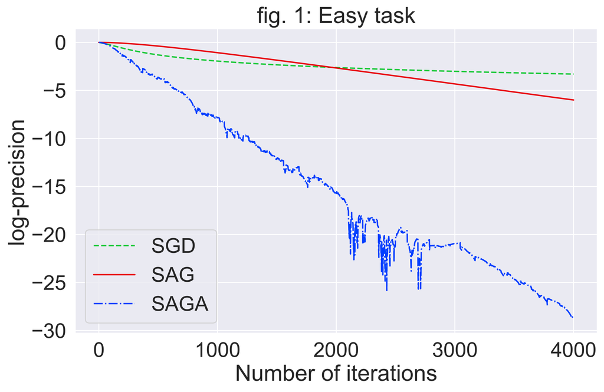

```python
plt.figure()
fig, ax = plt.subplots(figsize=(10, 6), dpi=600)
plt.plot(np.log(F_sgd), 'g--', label='SGD')
plt.plot(np.log(F_sag), 'r-', label='SAG')
plt.plot(np.log(F_saga), 'b-.', label='SAGA')
plt.legend(loc='lower left')
plt.xlabel('Number of iterations')
plt.ylabel('log-precision')
plt.title('fig. 1: Easy task')
plt.show()
```

The first chart (fig. $1$) illustrates this problem with the small dimension $n=m=k=40$. We see that SAGA is significantly better than SAG and SGD, it has a linear convergence rate, as predicted by the theory. It is harder to compare SGD and SAG on this graph because firstly SGD is faster, then SAG. To make it clearer, let's increase the dimensional value $n=m=k=400$ and the number of iterations.

```python
n = 400
nuli = np.zeros(n)
b = np.ones(n)*2
mu = np.ones(n)
alpha = np.ones(n)*4
A = np.eye(n)

steps = []
for i in range(n):
    si = np.outer(A[i],A[i])
    lamb = np.max(np.linalg.eigvalsh(si))
    L = lamb/mu[i]
    steps.append(L)

fopt = 2400
k = 100000
```

```python
######### SGD ##########

F_sgd = []

p = np.zeros(n)
x = x_opa(p)
f0 = f_opa(x)
F = np.abs(f_opa(x) - fopt)/(f0 - fopt)
F_sgd.append(F)
pj = 0

for j in range(k):
    i = rm.randint(0,n-1)
    p = p - 1/(2*steps[i]) * gradf(p,i)
    p = np.maximum(p,nuli)
    pj = (pj*j+p)/(j+1)
    x = x_opa(pj)
    F = np.abs(f_opa(x) - fopt)/(f0 - fopt)
    F_sgd.append(F)


######### SAG ##########

F_sag = []

p = np.zeros(n)
x = x_opa(p)
f0 = f_opa(x)
F = np.abs(f_opa(x) - fopt)/(f0 - fopt)
F_sag.append(F)
Y = np.zeros((n,n))

for j in range(n):
    Y[j] = gradf(p,j)

muka = f_muka_sum(p)

for j in range(k):
    i = rm.randint(0,n-1)
    ps = gradf(p,i)
    muka = (ps - Y[i])/n + muka
    p = p - 1/(16*steps[i]) * (muka)
    p = np.maximum(p,nuli)
    Y[i] = ps
    x = x_opa(p)
    F = np.abs((f_opa(x) - fopt)/(f0 - fopt))
    F_sag.append(F)


######### SAGA ##########

F_saga = []

p = np.zeros(n)
x = x_opa(p)
f0 = f_opa(x)
F = np.abs(f_opa(x) - fopt)/(f0 - fopt)
F_saga.append(F)
Y = np.zeros((n,n))

for j in range(n):
    Y[j] = gradf(p,j)

muka = f_muka_sum(p)

for _ in range(1,k):
    i = rm.randint(0,n-1)
    ps = gradf(p,i)
    muka = (ps - Y[i])/n + muka
    p = p - 1/(3*steps[i]) * ((ps - Y[i])*(n-1)/(n) + muka)
    p = np.maximum(p,nuli)
    Y[i] = ps
    x = x_opa(p)
    F = np.abs((f_opa(x) - fopt)/(f0 - fopt))
    F_saga.append(F)
```

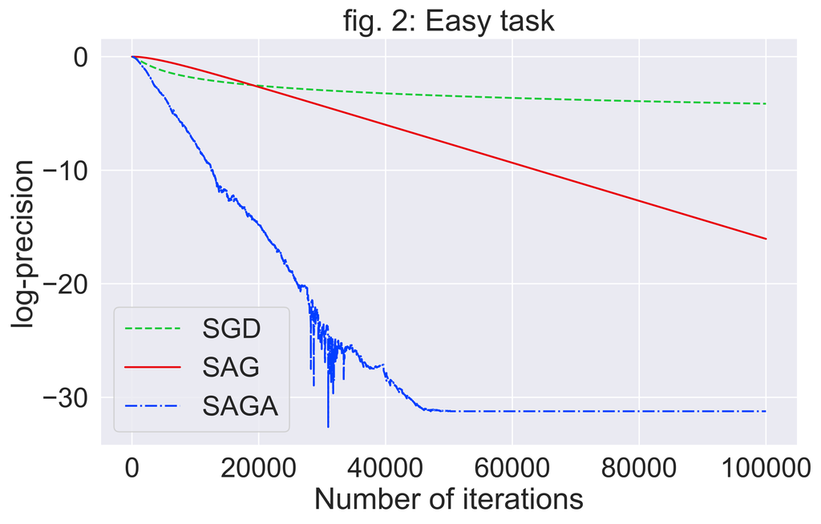

```python
plt.figure()
fig, ax = plt.subplots(figsize=(10, 6), dpi=600)
plt.plot(np.log(F_sgd), 'g--', label='SGD')
plt.plot(np.log(F_sag), 'r-', label='SAG')
plt.plot(np.log(F_saga), 'b-.', label='SAGA')
plt.legend(loc='lower left')
plt.xlabel('Number of iterations')
plt.ylabel('log-precision')
plt.title('fig. 2: Easy task')
plt.show()
```

On the new graph (fig. $2$) it is seen that SAGA is also the best. But now we can compare SGD and SAG. In the beginning SGD is also faster, this is because a step in SGD is much more than in SAG, but in the asymptotic expansion it can be seen that the rate of SAG convergence is linear, but less then by SAGA. SGD has sublinear rate. Thus, this example confirmed the theory that SGD converges, but has a sublinear slow convergence rate, SAG and SAGA have a linear convergence rate, while SAGA is significantly faster than SAG.

For the next example, we generated synthetic random data for all parameters. Consider the dimension of $40$.

```python
def x_opa(p):
    global alpha, A, mu, n
    vnutr = alpha - p.T.dot(A)
    return np.maximum(vnutr/mu,np.zeros(n))

def f_opa(x):
    global alpha, mu
    return alpha.dot(x) - mu.dot(x**2)/2

def gradf(p,i):
    global A, mu, b, alpha, n
    vnutr = alpha[i] - p.T.dot(A[i])
    if vnutr >= 0:
        return b[i]*A[i] - vnutr/mu[i] * A[i]
    else:
        return b[i]*A[i]

def f_muka_sum(p):
    global n
    Psum = 0
    for i in range(n):
        Psum = Psum + gradf(p,i)
    Psum = Psum/n
    return Psum
```

```python
n = 40
k = 40
m = 40
nuli = np.zeros(n)
alpha = np.random.randint(50, high=70, size=n)
mu = np.random.randint(1,2, size=n)
b = np.random.randint(50,70, size=n)
A = 2 * np.eye(n) + np.random.randint(0,2, size=(n,n))

steps = []
for i in range(n):
    si = np.outer(A[i],A[i])
    lamb = np.max(np.linalg.eigvalsh(si))
    L = lamb/mu[i]
    steps.append(L)

it = 120000
F_saga = []
p = np.zeros(n)
Y = np.zeros((n,n))

for j in range(n):
    Y[j] = gradf(p,j)

muka = f_muka_sum(p)

for _ in range(1,it):
    i = rm.randint(0,n-1)
    ps = gradf(p,i)
    muka = (ps - Y[i])/n + muka
    p = p - 1/(3*steps[i]) * ((ps - Y[i])*(n - 1)/(n) + muka)
    p = np.maximum(p,nuli)
    Y[i] = ps
    x = x_opa(p)
    F = f_opa(x)

fopt = F
it = 80000
```

```python
######### SGD ##########

F_sgd = []

p = np.zeros(n)
x = x_opa(p)
f0 = f_opa(x)
F = np.abs(f_opa(x)-fopt)/(f0-fopt)
F_sgd.append(F)
pj = 0

for j in range(it):
    i = rm.randint(0,n-1)
    p = p - 1/(((j+1)**(0.15))*steps[i]) * gradf(p,i)
    p = np.maximum(p,nuli)
    pj = (pj*j+p)/(j+1)
    x = x_opa(pj)
    F = np.abs(f_opa(x) - fopt)/(f0 - fopt)
    F_sgd.append(F)


######### SAG ##########

F_sag = []

p = np.zeros(n)
x = x_opa(p)
f0 = f_opa(x)
F = np.abs(f_opa(x) - fopt)/(f0 - fopt)
F_sag.append(F)
Y = np.zeros((n,n))

for j in range(n):
    Y[j] = gradf(p,j)

muka = f_muka_sum(p)

for j in range(it):
    i = rm.randint(0,n-1)
    ps=gradf(p,i)
    muka=(ps - Y[i])/n + muka
    p = p - 1/(16*steps[i]) * (muka)
    p = np.maximum(p,nuli)
    Y[i]= ps
    x = x_opa(p)
    F = np.abs((f_opa(x) - fopt)/(f0 - fopt))
    F_sag.append(F)


######### SAGA ##########

F_saga = []
p = np.zeros(n)
x = x_opa(p)
f0 = f_opa(x)
F = np.abs(f_opa(x) - fopt)/(f0 - fopt)
F_saga.append(F)
Y = np.zeros((n,n))

for j in range(n):
    Y[j] = gradf(p,j)

muka = f_muka_sum(p)

for _ in range(1,it):
    i = rm.randint(0,n-1)
    ps=gradf(p,i)
    muka=(ps - Y[i])/n + muka
    p = p - 1/(3*steps[i]) * ((ps - Y[i])*(n-1)/(n) + muka)
    p = np.maximum(p,nuli)
    Y[i]= ps
    x = x_opa(p)
    F = np.abs((f_opa(x) - fopt)/(f0 - fopt))
    F_saga.append(F)
```

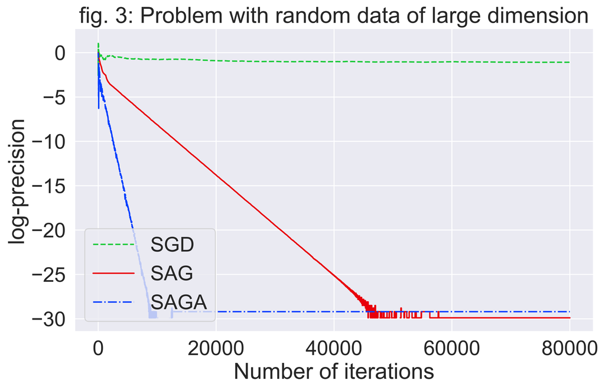

```python
plt.figure()
fig, ax = plt.subplots(figsize=(10, 6), dpi=600)
plt.plot(np.log(F_sgd), 'g--', label='SGD')
plt.plot(np.log(F_sag), 'r-', label='SAG')
plt.plot(np.log(F_saga), 'b-.', label='SAGA')
plt.legend(loc='lower left')
plt.xlabel('Number of iterations')
plt.ylabel('log-precision')
plt.title('fig. 3: Problem with random data of large dimension')
plt.show()
```

Now let's repeat calculations for the dimension $400$.

```python
n = 400
k = 40
m = 40
nuli = np.zeros(n)
alpha = np.random.randint(50, high=70, size=n)
mu = np.random.randint(1,2, size=n)
b = np.random.randint(50,70, size=n)
A = 2*np.eye(n)+np.random.randint(0,2, size=(n,n))

steps = []
for i in range(n):
    si = np.outer(A[i],A[i])
    lamb = np.max(np.linalg.eigvalsh(si))
    L = lamb/mu[i]
    steps.append(L)

it = 120000
p = np.zeros(n)
Y = np.zeros((n,n))

for j in range(n):
    Y[j] = gradf(p,j)

muka = f_muka_sum(p)

for _ in range(1,it):
    i = rm.randint(0,n-1)
    ps = gradf(p,i)
    muka = (ps - Y[i])/n + muka
    p = p - 1/(3*steps[i]) * ((ps - Y[i])*(n-1)/(n) + muka)
    p = np.maximum(p,nuli)
    Y[i] = ps
    x = x_opa(p)
    F = f_opa(x)

fopt = F
it = 80000
```

```python
######### SGD ##########

F_sgd = []

p = np.zeros(n)
x = x_opa(p)
f0 = f_opa(x)
F = np.abs(f_opa(x) - fopt)/(f0 - fopt)
F_sgd.append(F)
pj = 0

for j in range(it):
    i = rm.randint(0,n-1)
    p = p - 1/((np.maximum(15*(j+1)**(0.25), 1000-j))*steps[i]) * gradf(p,i)
    p = np.maximum(p,nuli)
    pj = (pj*j+p)/(j+1)
    x = x_opa(pj)
    F = np.abs(f_opa(x) - fopt)/(f0 - fopt)
    F_sgd.append(F)


######### SAG ##########

F_sag = []

p = np.zeros(n)
x = x_opa(p)
f0 = f_opa(x)
F = np.abs(f_opa(x) - fopt)/(f0 - fopt)
F_sag.append(F)
Y = np.zeros((n,n))

for j in range(n):
    Y[j] = gradf(p,j)

muka = f_muka_sum(p)

for j in range(it):
    i = rm.randint(0,n-1)
    ps = gradf(p,i)
    muka = (ps - Y[i])/n + muka
    p = p - 1/(16*steps[i]) * (muka)
    p = np.maximum(p,nuli)
    Y[i] = ps
    x = x_opa(p)
    F = np.abs((f_opa(x) - fopt)/(f0 - fopt))
    F_sag.append(F)


######### SAGA ##########

F_saga = []

p = np.zeros(n)
x = x_opa(p)
f0 = f_opa(x)
F = np.abs(f_opa(x) - fopt)/(f0 - fopt)
F_saga.append(F)
Y = np.zeros((n,n))

for j in range(n):
    Y[j] = gradf(p,j)

muka = f_muka_sum(p)

for _ in range(1,it):
    i = rm.randint(0,n-1)
    ps = gradf(p,i)
    muka = (ps - Y[i])/n + muka
    p = p - 1/(3*steps[i]) * ((ps - Y[i])*(n-1)/(n) + muka)
    p = np.maximum(p,nuli)
    Y[i] = ps
    x = x_opa(p)
    F = np.abs((f_opa(x) - fopt)/(f0 - fopt))
    F_saga.append(F)
```

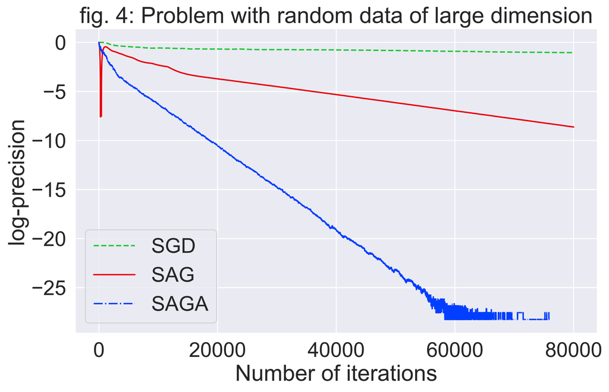

```python
plt.figure()
fig, ax = plt.subplots(figsize=(10, 6), dpi=600)
plt.plot(np.log(F_sgd), 'g--', label='SGD')
plt.plot(np.log(F_sag), 'r-', label='SAG')
plt.plot(np.log(F_saga), 'b-.', label='SAGA')
plt.legend(loc='lower left')
plt.xlabel('Number of iterations')
plt.ylabel('log-precision')
plt.title('fig. 4: Problem with random data of large dimension')
plt.show()
```

The $3$ and $4$ graphs also confirm the theory: SGD converges, but has a sublinear slow convergence rate and is significantly slower than its competitors, SAG and SAGA have a linear convergence rate, while SAGA is significantly faster than SAG.

## Summary

In our investigation, we modified 3 optimization methods for the resource allocation problem, gave them an economic interpretation, conducted numerical experiments, and compared the methods. The following conclusions can be drawn:

- for large-dimensional tasks, use SAGA;
- SAG converges with linear speed;
- SGD converges at sublinear speed.